# bootstrap

Authors

Affiliations

Félix Belzunce

Universidad de Murcia

María del Carmen Bueso, Pilar Sanmartín

Universidad Politécnica de Cartagena

## El conjunto de datos

Esta práctica se inspira de un [post](https://medium.com/@junaidsqazi/a41-bootstrapping-and-confidence-interval-behind-the-scene-9eb349dc8926) de Junaid Qazi. Usa un conjunto de datos asociados al videojuego Starcraft, un videojuego de estrategia en tiempo real de ciencia ficción militar, desarrollado por Blizzard Entertainment, donde los jugadores controlan distintas razas alienígenas o humanos en batallas tácticas intergalácticas.

[figure not shown]

Starcraft

Disponemos de un conjunto de datos de APM, que significa “Acciones Por Minuto”, es una medida utilizada en videojuegos, especialmente en los de estrategia en tiempo real, para indicar el número de acciones que un jugador puede realizar en un minuto, como clics y comandos del teclado. Refleja la rapidez y eficiencia con la que un jugador puede manejar múltiples tareas y tomar decisiones en el juego.

Después de descargar del aula virtual el fichero `bootstrapping.csv` en la carpeta `data` de vuestra carpeta de prácticas, y haber examinado su estructura, cargar los datos en un tibble llamado `starcraft`.

```r
library(tidyverse)
DATA_DIRECTORY <- "../data/"
starcraft <- read_csv(
  paste0(DATA_DIRECTORY, "bootstrapping.csv"),
  skip = 2,
  show_col_types = FALSE
)

starcraft
```

```
# A tibble: 200 × 1
     apm
   <dbl>
 1 191.
 2  77.6
 3  72.1
 4  91.3
 5  85.4
 6  62.0
 7 167.
 8  88.4
 9 110.
10 187.
# ℹ 190 more rows
```

## Primera exploración

- Obtener mínimo, máximo, primer y tercer cuartil, mediana y media.

```r
# Completar aquí
starcraft |>
  summarise(
    minimo = min(apm, na.rm = TRUE),
    q1 = quantile(apm, 0.25, na.rm = TRUE),
    mediana = median(apm, na.rm = TRUE),
    media = mean(apm, na.rm = TRUE),
    q3 = quantile(apm, 0.75, na.rm = TRUE),
    maximo = max(apm, na.rm = TRUE)
  )
```

```
# A tibble: 1 × 6
  minimo    q1 mediana media    q3 maximo
   <dbl> <dbl>   <dbl> <dbl> <dbl>  <dbl>
1   32.5  76.2    104.  114.  138.   390.
```

```r
# Fin Completar aquí
```

- Representar un resumen del conjunto con un “violin plot” al que añadáis los valores del conjunto. Consejo: como sólo tenemos una columna en el tibble, en `aes`, pasamos `x = ""`. En la salida, también se ha añadido un boxplot.

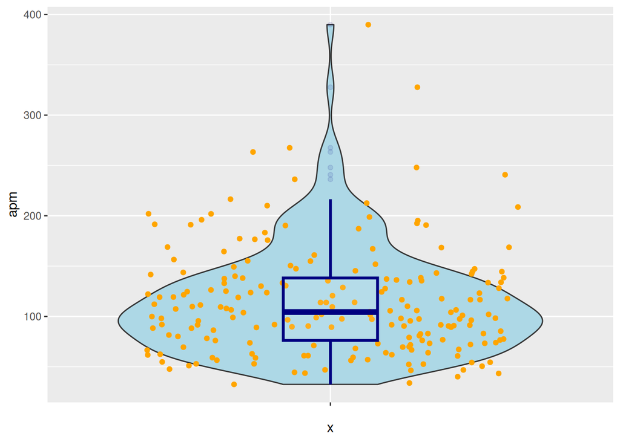

```r
starcraft |>
  ggplot(aes(x = "", y = apm)) +
  geom_violin(fill = "lightblue") +
  geom_jitter(color = "orange") +
  geom_boxplot(alpha = 0.1, width = 0.2, color = "navy", lwd = 1.1)
```

Constatamos que la distribución de los valores es asimétrica. Lo que también se puede apreciar con la diferencia entre media y mediana: la mediana se situa más a la izquierda porque es donde se concentran los datos.

Podemos también representar un histograma, por ejemplo con 50 clases.

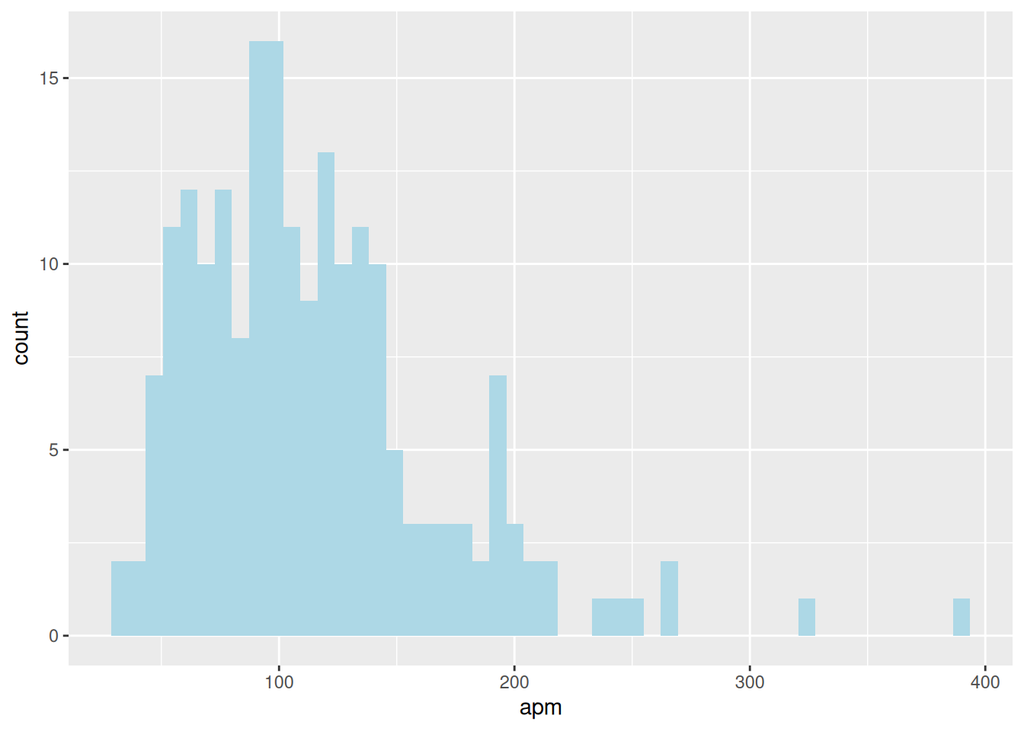

```r
starcraft |>
  ggplot(aes(x = apm)) +
  geom_histogram(bins = 50, fill = "lightblue")
```

**NoteNuestro objetivo:**

Queremos estimar, a partir de esta muestra, la mediana de apm de los jugadores de Starcraft en el mundo.

## Estimación de la mediana

Ya proporcionamos en el apartado anterior una estimación de la mediana de la población como la mediana de la muestra. Vamos ahora a:

- estimar el error estándar del estimador proporcionado usando 1000 muestras bootstrap.
- construir un intervalo de confianza al 90% basado en percentiles bootstrap.

### Simulación de 1000 muestras bootstrap

- Construir una lista de 1000 muestras bootstrap asociado a la muestra original de apms.

```r
set.seed(314159)
# Completar aquí
apm <- as.numeric(na.omit(starcraft$apm))
n <- length(apm)

lista_muestras_bootstrap <- map(
  seq_len(1000),
  \(i) sample(apm, size = n, replace = TRUE)
)

# Fin Completar aquí
head(lista_muestras_bootstrap[[1]])
```

```
[1] 210.0804  50.5584 109.4292  95.5650 201.9108 143.7180
```

### Estimación del error estándar de la mediana muestral

- Construir un vector `medianas_bootstrap` que contenga las medianas de las muestras bootstrap que hemos simulado

```r
# Completar aquí
medianas_bootstrap <- map_dbl(lista_muestras_bootstrap, median)

# Fin Completar aquí
head(medianas_bootstrap)
```

```
[1] 106.9737  99.0072  98.9547  99.3927  98.9547 101.5422
```

- Deducid una estimación del error estándar asociado a la mediana muestral.

```r
# Completar aquí
se_mediana <- sd(medianas_bootstrap)

# Fin Completar aquí
str_glue("El error estándar estimado de la mediana muestral es: {se_mediana}")
```

```
El error estándar estimado de la mediana muestral es: 4.0860799308481
```

- Deducid un intervalo de confianza al 90% para la mediana poblacional, usando una aproximación normal para la distribución muestral de la mediana muestral.

```r
# Completar aquí
mediana_muestral <- median(apm)
z_critico <- qnorm(0.95)

ic_normal_90 <- c(
  mediana_muestral - z_critico * se_mediana,
  mediana_muestral + z_critico * se_mediana
)

tibble(
  limite_inferior = ic_normal_90[1],
  limite_superior = ic_normal_90[2],
)
```

```
# A tibble: 1 × 2
  limite_inferior limite_superior
            <dbl>           <dbl>
1            97.7            111.
```

```r
# Fin Completar aquí
```

### Construcción de un IC al 90% basado en percentiles bootstrap

- Realizad un histograma de las medianas bootstrap.

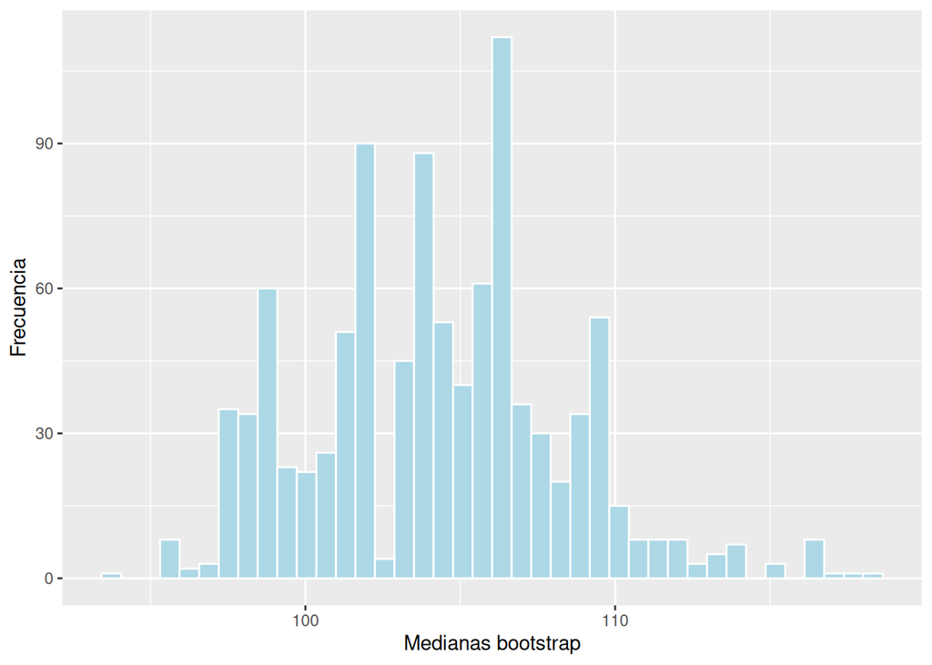

```r
# Completar aquí
tibble(mediana = medianas_bootstrap) |>
  ggplot(aes(x = mediana)) +
  geom_histogram(bins = 40, fill = "lightblue", color = "white") +
  labs(x = "Medianas bootstrap", y = "Frecuencia")
```

```r
# Fin Completar aquí
```

- Deducid un intervalo de confianza al 90% para la mediana poblacional, usando la construcción por percentiles bootstrap.

```r
# Completar aquí
ic_percentiles_90 <- quantile(medianas_bootstrap, probs = c(0.05, 0.95))

tibble(
  limite_inferior = ic_percentiles_90[1],
  limite_superior = ic_percentiles_90[2],
)
```

```
# A tibble: 1 × 2
  limite_inferior limite_superior
            <dbl>           <dbl>
1            97.8            111.
```

```r
# Fin Completar aquí
```

## Ejercicio

### Simulación de 5000 muestras bootstrap

- Construir una lista de 5000 muestras bootstrap asociado a la muestra original de apms.

```r
set.seed(314159)
# Completar aquí
apm <- as.numeric(na.omit(starcraft$apm))
n <- length(apm)

lista_muestras_bootstrap <- map(
  seq_len(5000),
  \(i) sample(apm, size = n, replace = TRUE)
)

# Fin Completar aquí
head(lista_muestras_bootstrap[[1]])
```

```
[1] 210.0804  50.5584 109.4292  95.5650 201.9108 143.7180
```

### Estimación del error estándar de la mediana muestral

- Construir un vector `medianas_bootstrap` que contenga las medianas de las muestras bootstrap que hemos simulado

```r
# Completar aquí
medianas_bootstrap <- map_dbl(lista_muestras_bootstrap, median)

# Fin Completar aquí
head(medianas_bootstrap)
```

```
[1] 106.9737  99.0072  98.9547  99.3927  98.9547 101.5422
```

- Deducid una estimación del error estándar asociado a la mediana muestral.

```r
# Completar aquí
se_mediana <- sd(medianas_bootstrap)

# Fin Completar aquí
str_glue("El error estándar estimado de la mediana muestral es: {se_mediana}")
```

```
El error estándar estimado de la mediana muestral es: 4.19836816858584
```

- Deducid un intervalo de confianza al 95% para la mediana poblacional, usando una aproximación normal para la distribución muestral de la mediana muestral.

```r
# Completar aquí
mediana_muestral <- median(apm)
z_critico <- qnorm(0.975)

ic_normal_95 <- c(
  mediana_muestral - z_critico * se_mediana,
  mediana_muestral + z_critico * se_mediana
)
# Fin Completar aquí
```

### Construcción de un IC al 95% basado en percentiles bootstrap

- Realizad un histograma de las medianas bootstrap.

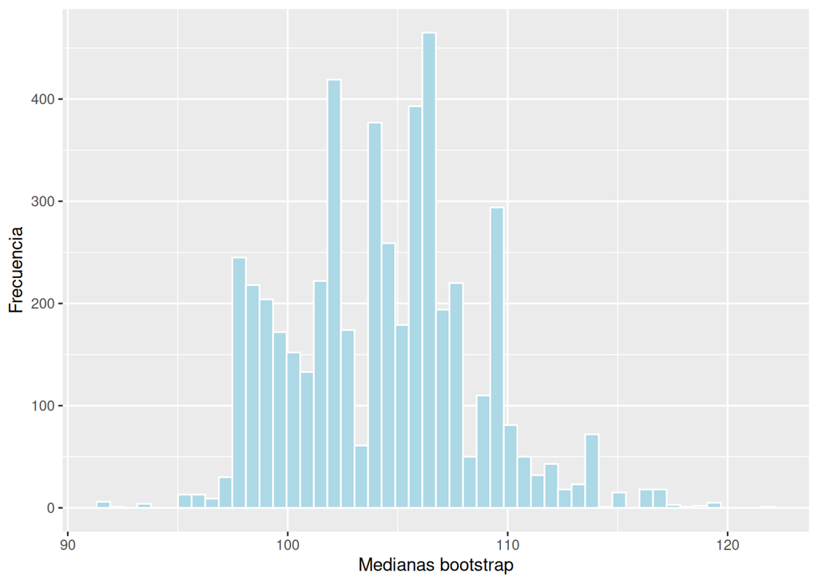

```r
# Completar aquí
tibble(mediana = medianas_bootstrap) |>
  ggplot(aes(x = mediana)) +
  geom_histogram(bins = 50, fill = "lightblue", color = "white") +
  labs(x = "Medianas bootstrap", y = "Frecuencia")
```

```r
# Fin Completar aquí
```

- Deducid un intervalo de confianza al 95% para la mediana poblacional, usando la construcción por percentiles bootstrap.

```r
# Completar aquí
ic_percentiles_95 <- quantile(medianas_bootstrap, probs = c(0.025, 0.975))

tibble(
  limite_inferior = ic_percentiles_95[1],
  limite_superior = ic_percentiles_95[2]
)
```

```
# A tibble: 1 × 2
  limite_inferior limite_superior
            <dbl>           <dbl>
1            97.5            114.
```

```r
# Fin Completar aquí
```